# BE vs ML results

#### R^2 == 0.5

```r
library(lavaan)
library(broom)
# generate data ------------------------------------------
sdat <- makeDat(
  N       = 10000,
  R2Y     = 0.2,
  R2eta   = 0.5,
  omega   = 0.2,
  tau0    = 0.4,
  tau1    = -0.2,
  linear  = T,
  ydist   = 'n',
  lambda  = 0.5,
  nsec    = 10,
  nfac    = 1,
  lvmodel = '2pl'
)

X <- sdat$x
theta <- sdat$theta
Y <- sdat$stan_dt$Y
Z <- sdat$stan_dt$Z

datax <- data.frame(X1 = X[,1], X2 = X[,2], Z, theta, Ztheta = Z*theta, Y)
round(colMeans(datax), 3); round(cov(datax), 3)
```

```
##     X1     X2      Z  theta Ztheta      Y
##  0.011  0.484  0.500  0.235  0.121  0.000
```

```
##            X1     X2     Z  theta Ztheta      Y
## X1      0.986 -0.002 0.000 -0.667 -0.339  0.324
## X2     -0.002  0.250 0.002  0.119  0.061  0.091
## Z       0.000  0.002 0.250  0.004  0.061  0.088
## theta  -0.667  0.119 0.004  1.000  0.502 -0.122
## Ztheta -0.339  0.061 0.061  0.502  0.516 -0.096
## Y       0.324  0.091 0.088 -0.122 -0.096  0.999
```

```r
lm(theta ~ X1 + X2, data = datax) %>% summary()
```

```
##
## Call:
## lm(formula = theta ~ X1 + X2, data = datax)
##
## Residuals:
##      Min       1Q   Median       3Q      Max
## -2.88445 -0.47483 -0.00575  0.48537  2.59398
##
## Coefficients:
##              Estimate Std. Error t value Pr(>|t|)
## (Intercept)  0.015190   0.009777   1.554     0.12
## X1          -0.675753   0.007072 -95.556   <2e-16 ***
## X2           0.468743   0.014052  33.357   <2e-16 ***
## ---
## Signif. codes:  0 '***' 0.001 '**' 0.01 '*' 0.05 '.' 0.1 ' ' 1
##
## Residual standard error: 0.7023 on 9997 degrees of freedom
## Multiple R-squared:  0.5068, Adjusted R-squared:  0.5067
## F-statistic:  5136 on 2 and 9997 DF,  p-value: < 2.2e-16
```

```r
lm(Y ~ X1 + X2 + Z + theta + Ztheta, data = datax) %>% summary()
```

```
##
## Call:
## lm(formula = Y ~ X1 + X2 + Z + theta + Ztheta, data = datax)
##
## Residuals:
##     Min      1Q  Median      3Q     Max
## -3.5188 -0.6091  0.0007  0.5908  3.4101
##
## Coefficients:
##             Estimate Std. Error t value Pr(>|t|)
## (Intercept) -0.37877    0.01554  -24.38   <2e-16 ***
## X1           0.40036    0.01255   31.89   <2e-16 ***
## X2           0.31405    0.01901   16.52   <2e-16 ***
## Z            0.39633    0.01851   21.41   <2e-16 ***
## theta        0.21506    0.01563   13.76   <2e-16 ***
## Ztheta      -0.21560    0.01803  -11.96   <2e-16 ***
## ---
## Signif. codes:  0 '***' 0.001 '**' 0.01 '*' 0.05 '.' 0.1 ' ' 1
##
## Residual standard error: 0.9011 on 9994 degrees of freedom
## Multiple R-squared:  0.1875, Adjusted R-squared:  0.1871
## F-statistic: 461.4 on 5 and 9994 DF,  p-value: < 2.2e-16
```

```r
fit <- sem('
Y ~ X1 + X2 + Z + theta + Ztheta
theta ~ X1 + X2
', data = datax, meanstructure = T)

summary(fit, standardized = TRUE)
```

```
## lavaan 0.6-11 ended normally after 19 iterations
##
##   Estimator                                         ML
##   Optimization method                           NLMINB
##   Number of model parameters                        11
##
##   Number of observations                         10000
##
## Model Test User Model:
##
##   Test statistic                              3943.023
##   Degrees of freedom                                 2
##   P-value (Chi-square)                           0.000
##
## Parameter Estimates:
##
##   Standard errors                             Standard
##   Information                                 Expected
##   Information saturated (h1) model          Structured
##
## Regressions:
##                    Estimate  Std.Err  z-value  P(>|z|)   Std.lv  Std.all
##   Y ~
##     X1                0.400    0.014   29.576    0.000    0.400    0.393
##     X2                0.314    0.019   16.249    0.000    0.314    0.155
##     Z                 0.396    0.018   21.579    0.000    0.396    0.196
##     theta             0.215    0.013   16.762    0.000    0.215    0.213
##     Ztheta           -0.216    0.015  -14.569    0.000   -0.216   -0.153
##   theta ~
##     X1               -0.676    0.007  -95.570    0.000   -0.676   -0.671
##     X2                0.469    0.014   33.362    0.000    0.469    0.234
##
## Intercepts:
##                    Estimate  Std.Err  z-value  P(>|z|)   Std.lv  Std.all
##    .Y                -0.379    0.015  -24.467    0.000   -0.379   -0.375
##    .theta             0.015    0.010    1.554    0.120    0.015    0.015
##
## Variances:
##                    Estimate  Std.Err  z-value  P(>|z|)   Std.lv  Std.all
##    .Y                 0.812    0.011   70.711    0.000    0.812    0.795
##    .theta             0.493    0.007   70.711    0.000    0.493    0.493
```

## Non-convergence

- nConv : Converged replications
- nWarn : replications with warnings (for Bayes, the replications with 1.1 < Rhat < 1.2)
- nError : Errors, non-convergence (no output at all in mplus; for Bayes, the replications with Rhat > 1.2)

[output not shown]

## Bias

- Each dot indicates errors (estimate - true) of each replication.
- Item slopes and intercepts are averaged
- SE: Standard Errors for ML / Standard deviations for Bayes
- Red dot indicates the bias (the mean of errors)
- All non-converged replications are excluded (For Bayes, the replications with Rhat < 1.2 are used (not 1.1))

### Item intercept

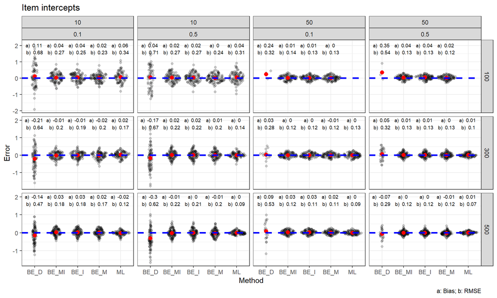

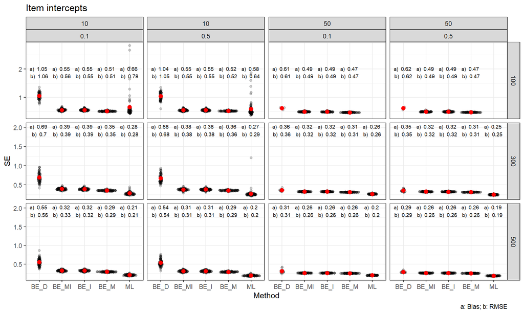

### Item Slope

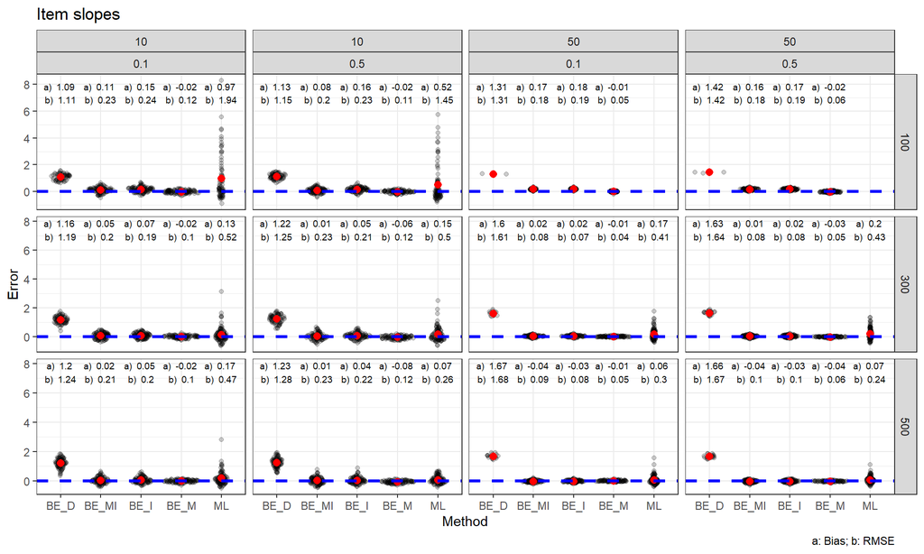

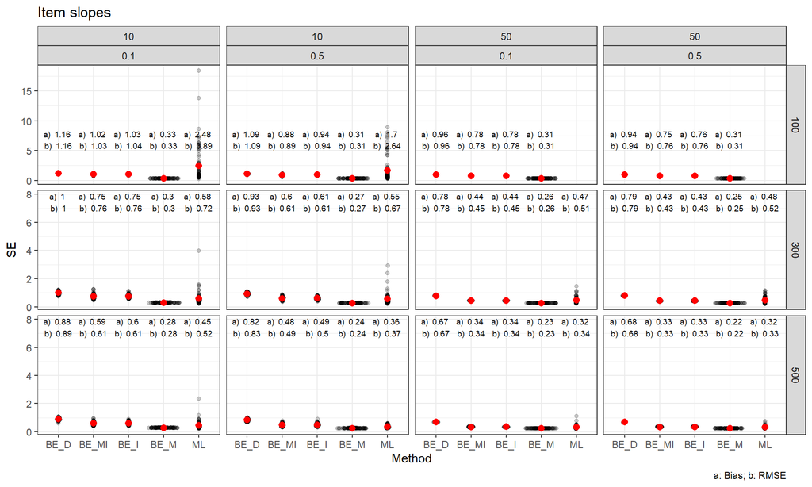

### Omega

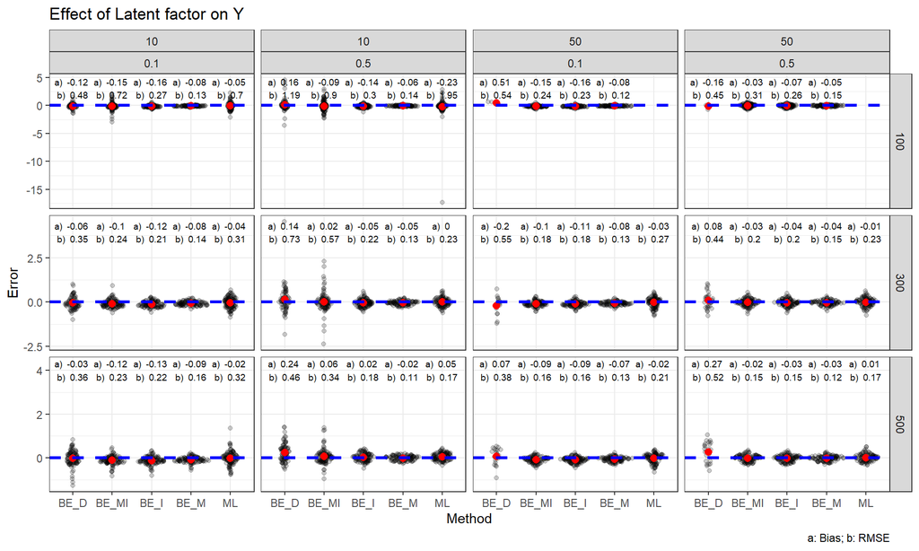

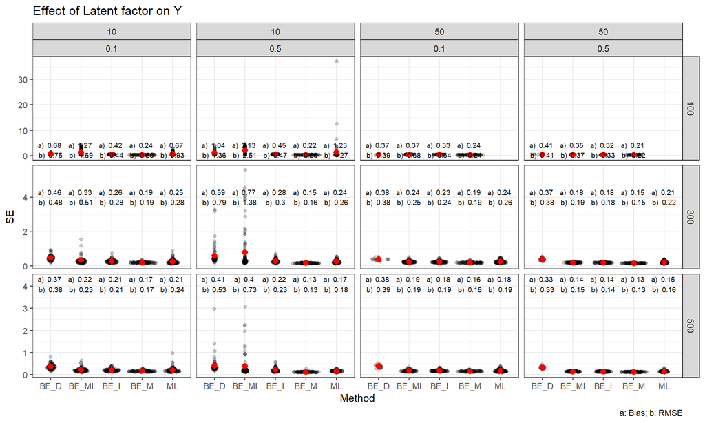

### Principal effects (tau1)

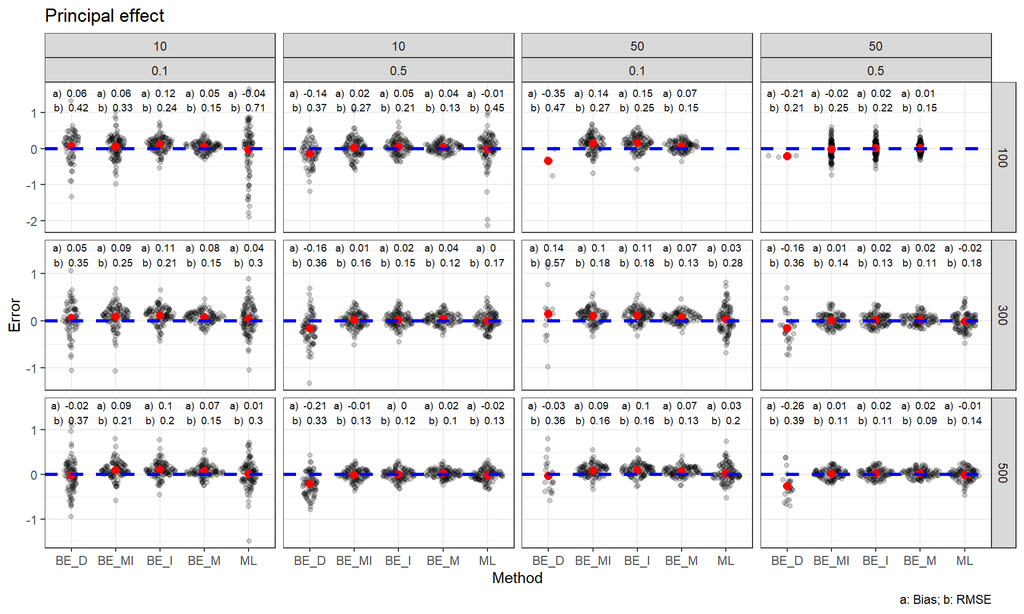

### Effects of Z on Y (tau0)

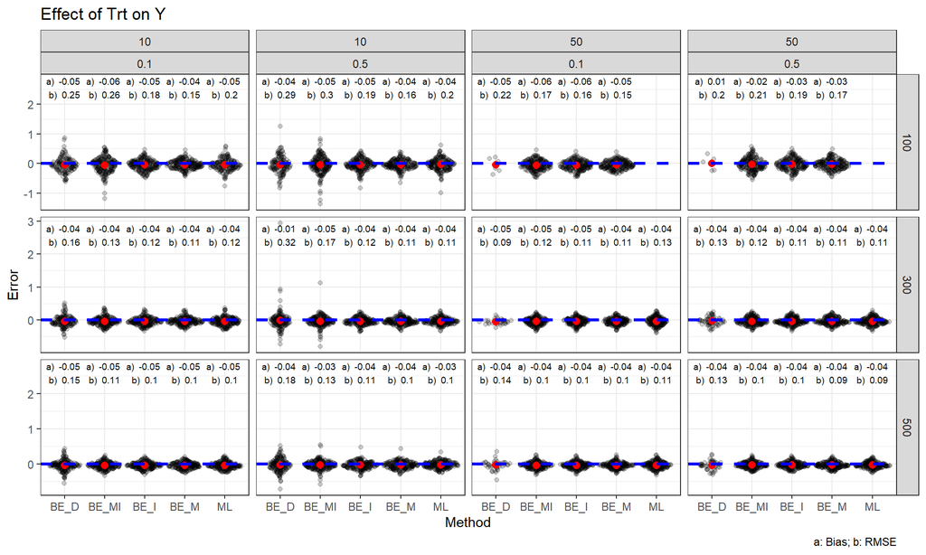

### Effects of covariates on latent factor

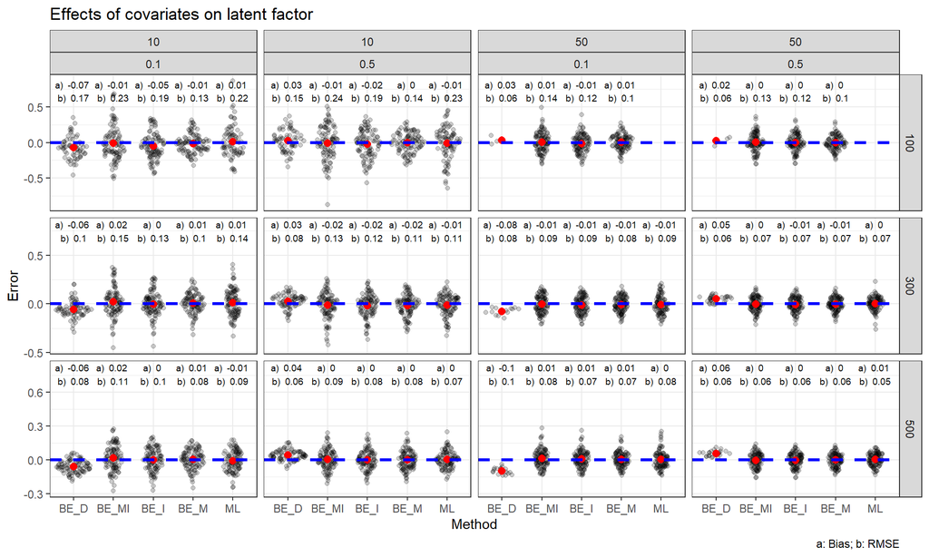

### Effects of covariates on Y

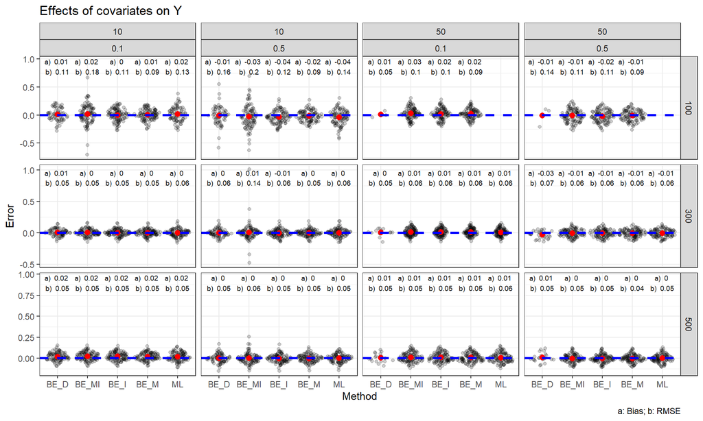

## MSE Ratio

- MSE ratio = MSE of ML / MSE of Bayesian
  - Higher MSE ratio -> better (smaller) MSE in Bayesian
- When MSE ratio = 1, no difference in MSE

### Item intercept

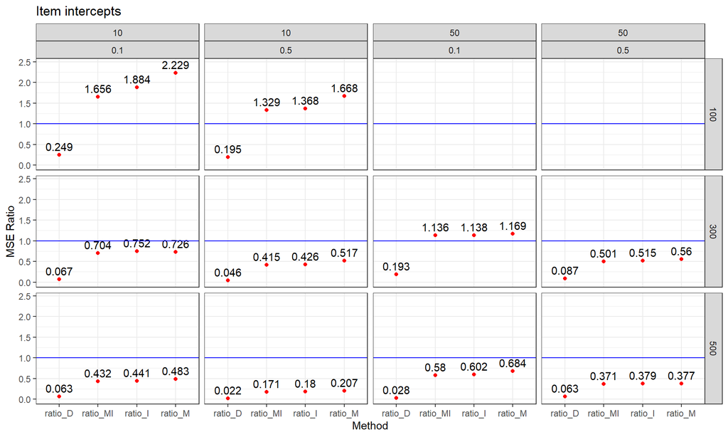

### Item Slope

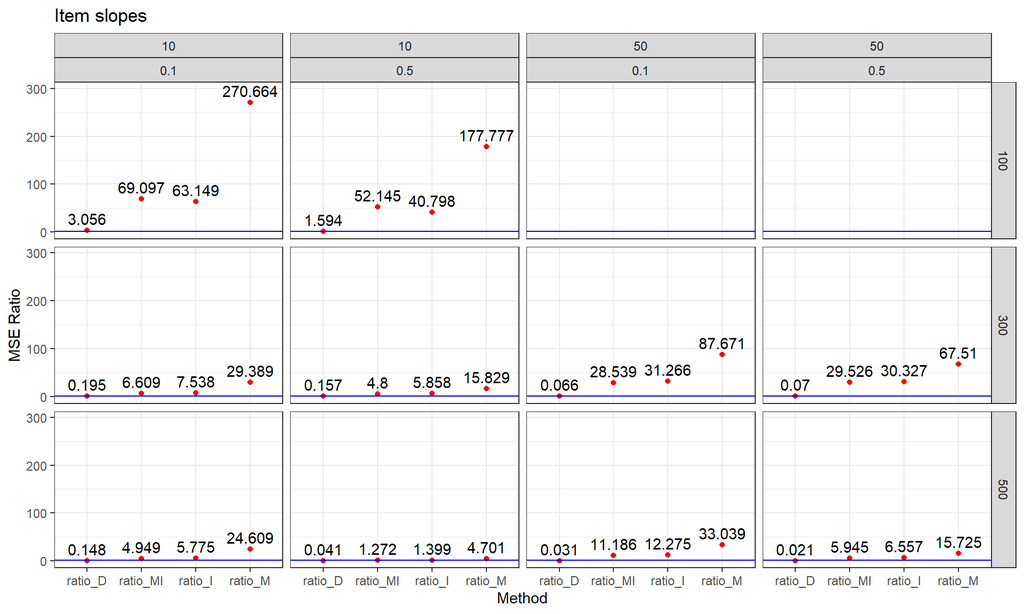

### Omega

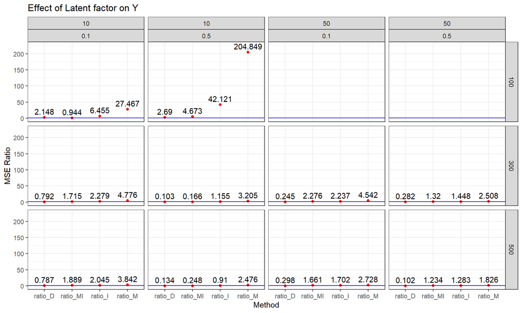

### Principal effects (tau1)

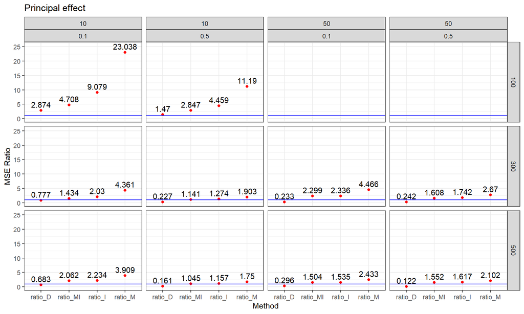

### Effects of Z on Y (tau0)

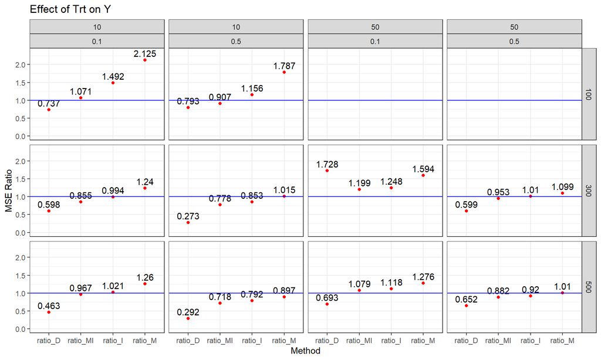

### Effects of covariates on latent factor

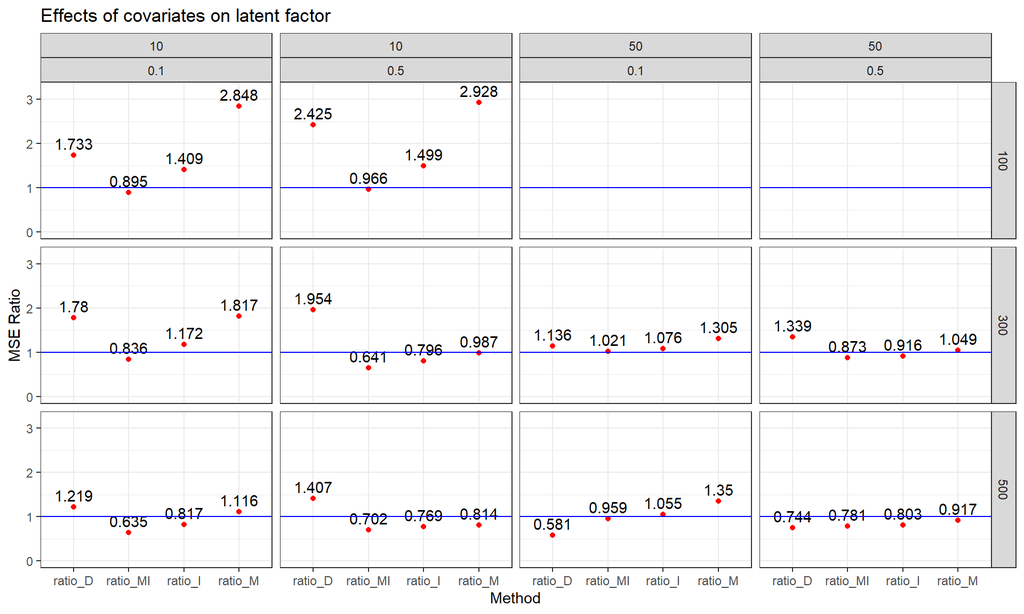

### Effects of covariates on Y

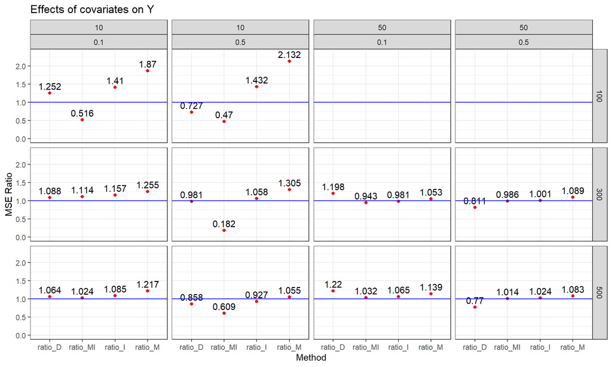